# Estimating Flood Inundation Probability Map

Lu Yii Wong & Yujin Song

2024-03-22

# 1: Introduction

## 1.1: Context of Flooding in Calgary

The city of Calgary is located in Alberta, Canada. According to the national census, Calgary had a population of 1,306,784 in 2021 [(Statistics Canada)](https://www12.statcan.gc.ca/census-recensement/2021/search-recherche/productresults-resultatsproduits-eng.cfm?LANG=E&GEOCODE=2021A00054806016). Calgary has a dry climate, however, because of its proximity to mountains, the city is vulnerable to “unpredictable swings in the weather from heavy rains leaving to floods to many weeks of dry temperatures and little rain leading to droughts.” [(Calgary.ca)](https://www.calgary.ca/water/flooding.html)

In 2013, the city experienced a devastating flood. The flood was caused by “melting snowpack in the Rocky mountains combined with steep, rocky terrain caused rapid and intense flooding in southern-Alberta watersheds.” [(Calgary.ca)](https://www.calgary.ca/water/flooding/history-calgary.html) This flood resulted in one fatality, injuries, and massive infrastructure damage. The estimated damages from this flooding event are over $6 billion across southern Alberta. This natural disaster resulted in tremendous infrastructure loss, the financial burden in recovery, and trauma for Calgary residents impacted.

## 1.2: Planning Motivation

Our team believes that studying flood inundation risk is important to prepare our cities for future impacts of flooding. Modeling flood inundation will inform planners and policymakers on high-flood risk areas. With this knowledge, we can plan for the future by recommending plans and policies to curb future development in high-risk regions and protect moderate-risk areas.

For this exercise, our team used Calgary as our case study to examine physical features correlated to flood risk. Based on our data exploration, we built a model to predict future flooding in Calgary, tested its performance, and applied it to a comparable city. Additionally, we chose Denver, a city in Colorado, United States, as our comparable city due to its similarities in climate. Our model is an example of the potential application of predictive models across various cities to predict flood risk using a city’s physical features.

## 1.3: Setting Up Libraries

## 1.4: Load Data

```r
# dependent variable
inundation <- read.csv("C:\\Users\\USER\\Desktop\\LandUseModeling\\Assignment3\\Calgary\\table\\zonal_depe.csv")
# independent variables
elevation <- read.csv("C:\\Users\\USER\\Desktop\\LandUseModeling\\Assignment3\\Calgary\\table\\zonal_elev.csv")

flow_acc <- read.csv("C:\\Users\\USER\\Desktop\\LandUseModeling\\Assignment3\\Calgary\\table\\zonal_fac.csv")

land_use <- read.csv("C:\\Users\\USER\\Desktop\\LandUseModeling\\Assignment3\\Calgary\\table\\zonal_lulc.csv")

slope <- read.csv("C:\\Users\\USER\\Desktop\\LandUseModeling\\Assignment3\\Calgary\\table\\zonal_slope.csv")

water_body <- read.csv("C:\\Users\\USER\\Desktop\\LandUseModeling\\Assignment3\\Calgary\\table\\zonal_water.csv")
```

# 2: Exploratory Analysis

## 2.1: Model Hypothesis

**Hypothesizing Factors that Increase Flood Risk:**

1. **Waterbody**: The closer an area is to a water body, the higher the probability of flooding to occur.
2. **Elevation**: Areas with low elevation have a higher probability of flood occurrence than high-elevation areas.
3. **Slope**: As the steepness of the slope increases in an area, the probability of flood inundation decreases.
4. **Flow accumulation**: The greater the flow accumulation in an area, the higher the probability of flood occurrence.
5. **Land use and land cover**: Urban and built-up areas are more likely to flood due to their high concentration of impermeable surfaces, compared to rural and undeveloped areas with higher concentrations of permeable surfaces.

## 2.2: Understanding Past Flood Inundation

Here, we used 1-kilometer by 1-kilometer lattice grid cells (known as a fishnet) to express data uniformly across Calgary. Figure 2.1 shows past flooding incidents in Calgary, displayed using grid cells. We chose to use a 1-kilometer squared grid cell to ensure that an area we predict to be at risk of flooding covers a sizable portion of land that is big enough to encompass a neighborhood but small enough to be useful in our analysis.

```r
calgary_fishnet<-st_read("C:\\Users\\USER\\Desktop\\LandUseModeling\\Assignment3\\Calgary\\json\\Calgary_Fishnet.json")
calgary_boundary<-st_read("C:\\Users\\USER\\Desktop\\LandUseModeling\\Assignment3\\Calgary\\json\\Calgary_Boundary.json")
```

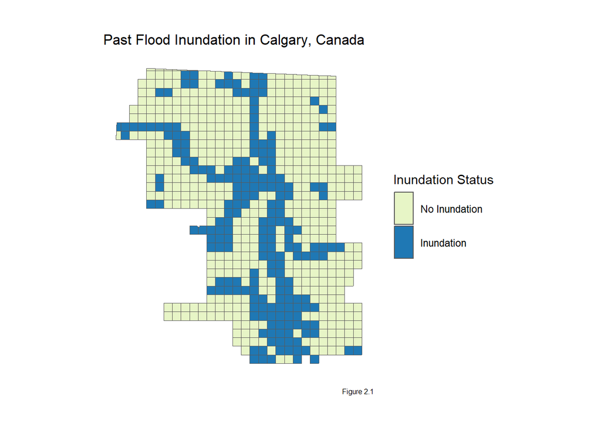

```r
calgary_Floods <- calgary_fishnet %>%
  left_join(inundation, by = "FID")

calgary_Floods$RANGE<-as.factor(calgary_Floods$RANGE)

ggplot() +
  geom_sf(data=calgary_fishnet,color="grey",size=0.2) +
  geom_sf(data=calgary_Floods ,aes(fill=RANGE),size=0.5) +
   scale_fill_manual(values = c("1"= "#1f78b4", "0" = "#e7f5c6"),
                     labels = c("1" = "Inundation", "0" = "No Inundation"),
                  name = "Inundation Status") +
  labs(title="Past Flood Inundation in Calgary, Canada",
       caption = "Figure 2.1")+
  mapTheme+
    guides(fill = guide_legend(override.aes = list(shape = 22, size = 6)))
```

## 2.3: Data Exploration

After testing multiple features, our team decided to include flood accumulation, distance to a water body, slope steepness, elevation, and surface permeability in the model. We considered geographical, hydrological, and physical attributes when selecting our variables. Using our team’s expert knowledge of urban flooding, we wanted to account for variables that could increase the risk of pluvial and fluvial flooding. Pluvial flooding occurs due to heavy rainfall, independent of proximity to a water body. In contrast, fluvial flooding occurs when a water body overflows [(Resources for the Future)](https://www.rff.org/publications/explainers/flooding-in-the-united-states-101-causes-trends-and-impacts/#:~:text=and%20move%20faster.-,Pluvial,water%20floods%20and%20flash%20floods.). We believe this was an important consideration for our model, as Calgary is vulnerable to both types of flooding.

**The statistically significant original features that we engineered were:**

- Mean Flood Accumulation
- Minimum Distance from Water Body
- Maximum Steepness of Slope
- Mean Elevation

Moreover, we added surface permeability in our model as we believe it might be an important factor contributing to pluvial floods from surface runoff. We categorized permeability using a threshold for each 1-kilometer square fishnet cell. A cell with less than 25% of urban land cover was categorized as permeable. A cell with more than 25% of urban land cover was categorized as impermeable.

```r
library(raster)
#Inundation Calgary
dependent <- raster("C:/Users/USER/Desktop/LandUseModeling/Assignment3/calgary_raster/dependent.tif")
dependent_df <- as.data.frame(dependent, xy = TRUE)
fishnet_shp<- st_read("C:/Users/USER/Desktop/LandUseModeling/Assignment3/Calgary/fishnet_boundary.shp")
st_geometry_type(fishnet_shp)
```

```
## [1] POLYGON
## 18 Levels: GEOMETRY POINT LINESTRING POLYGON MULTIPOINT ... TRIANGLE
```

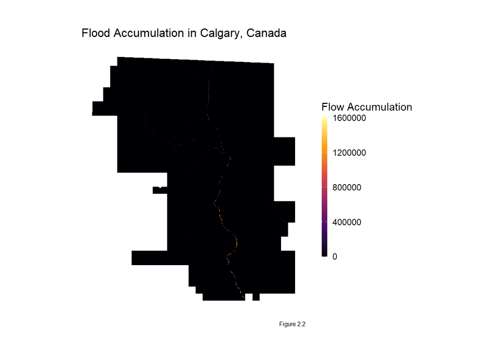

```r
calfishnet_shp <- st_zm(fishnet_shp, drop = TRUE)
clipped_depen <- mask(dependent,calfishnet_shp)
clip_df <-as.data.frame(clipped_depen, xy=TRUE)

library(viridis)
#Flow accumulation
calgary_fac<-raster("C:/Users/USER/Desktop/LandUseModeling/Assignment3/calgary_raster/Calgary_fac.tif")
clipped_cal_fac <- mask(calgary_fac,calfishnet_shp)
cal_fac_df <-as.data.frame(clipped_cal_fac, xy=TRUE)

ggplot() +
    geom_raster(data = cal_fac_df , aes(x = x, y = y, fill =Calgary_fac)) +
 scale_fill_viridis_c(name = "Flow Accumulation", option = "inferno", na.value = "transparent",
  limits = c(min(cal_fac_df$Calgary_fac, na.rm = TRUE), max(cal_fac_df$Calgary_fac, na.rm = TRUE) *1.01))+
  coord_sf() +
  labs(title = "Flood Accumulation in Calgary, Canada",
       caption = "Figure 2.2") +
  mapTheme
```

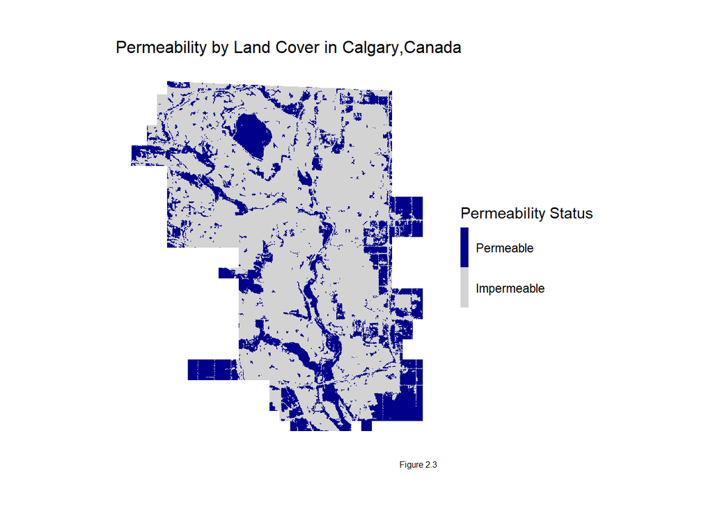

```r
#permeability
calgary_perme<-raster("C:/Users/USER/Desktop/LandUseModeling/Assignment3/calgary_raster/calgary_perme.tif")

clipped_cal_perme <- mask(calgary_perme,calfishnet_shp)
cal_perme_df <-as.data.frame(clipped_cal_perme, xy=TRUE)

cal_perme_df$calgary_perme<-factor(cal_perme_df$calgary_perme)

ggplot() +
  geom_raster(data = cal_perme_df, aes(x = x, y = y, fill = calgary_perme)) +
  geom_tile() +
  scale_fill_manual(values = c("1" = "#D3D3D3", "0" = "#00008B"),
                    labels = c("1" = "Impermeable", "0" = "Permeable"),
                    name = "Permeability Status",
                     na.value = "transparent") +
  coord_sf() +
  labs(title = "Permeability by Land Cover in Calgary,Canada",
       caption = "Figure 2.3") +
  mapTheme
```

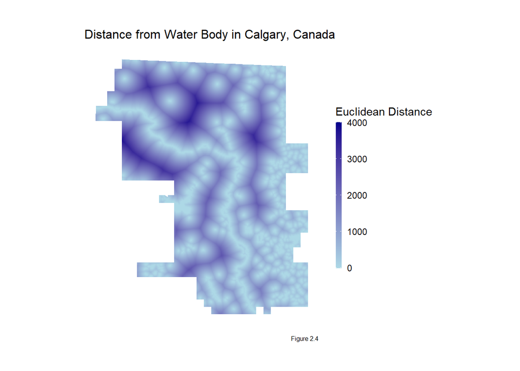

```r
#Distance from water Body
calgary_water<-raster("C:/Users/USER/Desktop/LandUseModeling/Assignment3/calgary_raster/calgary_water.tif")
clipped_cal_water <- mask(calgary_water,calfishnet_shp)
cal_water_df <-as.data.frame(clipped_cal_water, xy=TRUE)


ggplot() +
  geom_raster(data = cal_water_df, aes(x = x, y = y, fill = calgary_water)) +
  scale_fill_gradient(name = "Euclidean Distance",
                      low = "lightblue", high = "darkblue",
                      na.value = "transparent",
                      limits = c(NA, 4000)) +  # Explicitly set the upper limit to 4000
  coord_sf() +
  labs(title = "Distance from Water Body in Calgary, Canada",
       caption = "Figure 2.4") +
  mapTheme
```

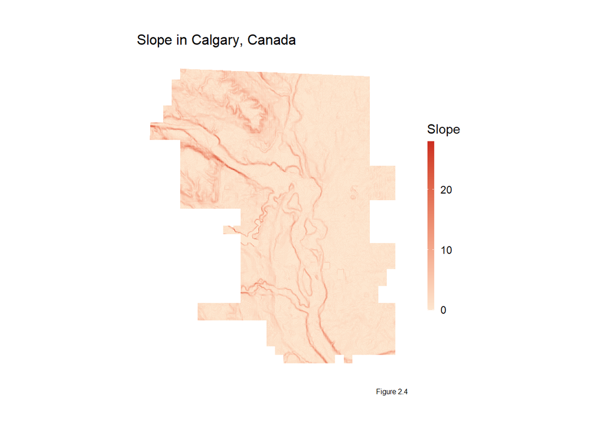

```r
#slope
calgary_slope<-raster("C:/Users/USER/Desktop/LandUseModeling/Assignment3/calgary_raster/calgary_slope.tif")
clipped_cal_slope <- mask(calgary_slope,calfishnet_shp)
cal_slope_df <-as.data.frame(clipped_cal_slope, xy=TRUE)

ggplot() +
    geom_raster(data = cal_slope_df , aes(x = x, y = y, fill =calgary_slope)) +
    scale_fill_gradient(name = "Slope",
                      low = "#FDE6CF", high = "#CC2D20",
                      na.value = "transparent",
                      limits = c(NA, 28)) +
  coord_sf() +
      labs(title = "Slope in Calgary, Canada",
       caption = "Figure 2.4") +
  mapTheme
```

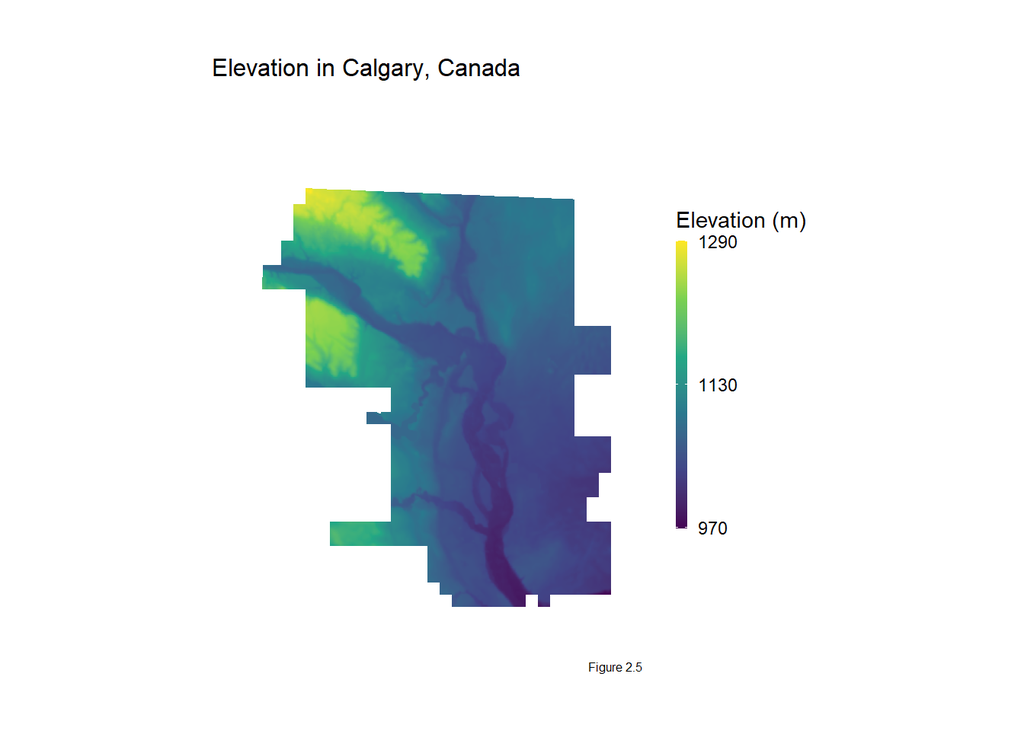

```r
#Elevation

calgary_dem<-raster("C:/Users/USER/Desktop/LandUseModeling/Assignment3/calgary_raster/calgary_dem.tif")

clipped_cal_dem <- mask(calgary_dem,calfishnet_shp)
cal_dem_df <-as.data.frame(clipped_cal_dem, xy=TRUE)

lowest_value <- 970
highest_value <- 1290

ggplot() +
  geom_raster(data = cal_dem_df, aes(x = x, y = y, fill = calgary_dem)) +
  scale_fill_viridis_c(name = "Elevation (m)",
                       na.value = "transparent",
                       limits = c(lowest_value, highest_value),
                       breaks = c(lowest_value, (lowest_value+highest_value)/2, highest_value),
                       labels = c(as.character(lowest_value), as.character((lowest_value+highest_value)/2), as.character(highest_value))) +
  coord_sf() +
  labs(title = "Elevation in Calgary, Canada",
       caption = "Figure 2.5") +
mapTheme
```

# 3: Model Building and Validation

## 3.1: Partition Training and Test Sets

```r
# Combine all data sets for model building
model_data <- flood_dep %>%
  inner_join(elev_comb, by = "FID") %>%
  inner_join(slope_comb, by = "FID") %>%
  inner_join(water_comb, by = "FID") %>%
  inner_join(fac_comb, by = "FID") %>%
  inner_join(lu_comb, by = "FID") %>%
  mutate(permeability = as.factor(permeability))

#land cover is dummy var and categorical var


# Creating training and test sets
set.seed(3456)
trainIndex <- createDataPartition(model_data$permeability, p = .70,
                                  list = FALSE,
                                  times = 1)

floodTrain <- model_data[ trainIndex,]
floodTest  <- model_data[-trainIndex,]
```

## 3.2: Making the Binomial Model

```r
library(dplyr)

floodModel <- glm(flood ~ .,
                  family = binomial(link = "logit"),
                  data = floodTrain %>%
                          as.data.frame() %>%
                          dplyr::select(-FID))
summary(floodModel)
```

```
##
## Call:
## glm(formula = flood ~ ., family = binomial(link = "logit"), data = floodTrain %>%
##     as.data.frame() %>% dplyr::select(-FID))
##
## Coefficients:
##                  Estimate Std. Error z value Pr(>|z|)
## (Intercept)     6.7599120  3.4378350   1.966  0.04926 *
## mean_elev      -0.0097116  0.0032883  -2.953  0.00314 **
## max_slope       0.2900484  0.0345296   8.400  < 2e-16 ***
## min_dist_water -0.0018497  0.0003955  -4.677 2.91e-06 ***
## mean_fac        0.0006894  0.0001612   4.278 1.89e-05 ***
## permeability1   1.0437304  0.4958277   2.105  0.03529 *
## ---
## Signif. codes:  0 '***' 0.001 '**' 0.01 '*' 0.05 '.' 0.1 ' ' 1
##
## (Dispersion parameter for binomial family taken to be 1)
##
##     Null deviance: 585.95  on 476  degrees of freedom
## Residual deviance: 315.59  on 471  degrees of freedom
## AIC: 327.59
##
## Number of Fisher Scoring iterations: 7
```

## 3.3: Model Validation

Figure 3.1 shows the distribution of predicted probabilities by observed outcome for flooding and no flooding. At a 0.5 threshold, we observe that the model is better at correctly predicting “No Flood” instances over “Flood.”

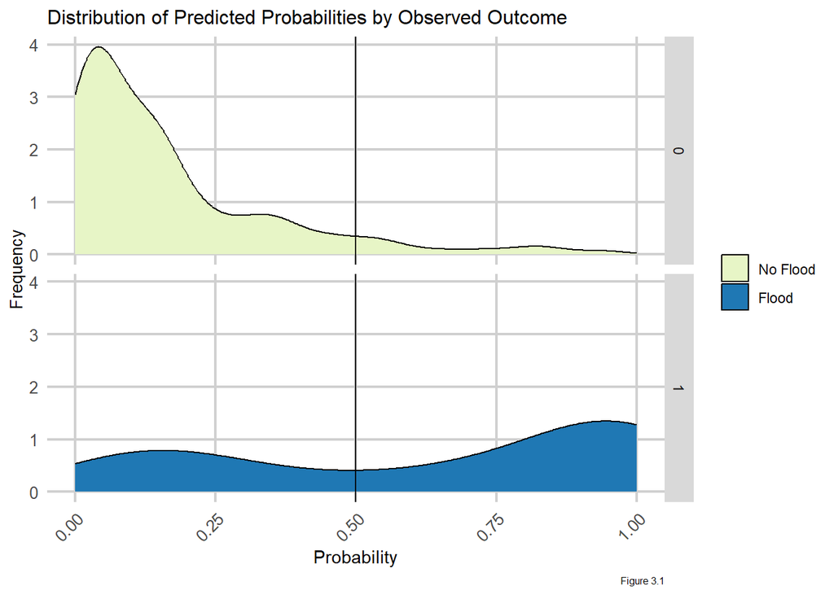

```r
classProbs <- predict(floodModel, floodTest, type="response")

# hist(classProbs, col = "#1f78b4", main = "Histogram of Flood Probabilities")

# testing probabilities
testProbs <- data.frame(obs = as.factor(floodTest$flood),
                        pred = classProbs)

ggplot(testProbs, aes(x = pred, fill=as.factor(obs))) +
  geom_density() +
  facet_grid(obs ~ .) +
  xlab("Probability") +
  ylab("Frequency")+
  geom_vline(xintercept = .5) +
  labs(title="Distribution of Predicted Probabilities by Observed Outcome",
       caption = "Figure 3.1")+
  scale_fill_manual(values = c("#e7f5c6", "#1f78b4"),
                      labels = c("No Flood","Flood"),
                      name = "")+
  plotTheme
```

## 3.4: Confusion Matrix

```r
testProbs$predClass  = ifelse(testProbs$pred > .5 ,1,0)

caret::confusionMatrix(reference = as.factor(testProbs$obs),
                       data = as.factor(testProbs$predClass),
                       positive = "1")
```

```
## Confusion Matrix and Statistics
##
##           Reference
## Prediction   0   1
##          0 130  23
##          1  10  40
##
##                Accuracy : 0.8374
##                  95% CI : (0.7793, 0.8854)
##     No Information Rate : 0.6897
##     P-Value [Acc > NIR] : 1.114e-06
##
##                   Kappa : 0.5974
##
##  Mcnemar's Test P-Value : 0.03671
##
##             Sensitivity : 0.6349
##             Specificity : 0.9286
##          Pos Pred Value : 0.8000
##          Neg Pred Value : 0.8497
##              Prevalence : 0.3103
##          Detection Rate : 0.1970
##    Detection Prevalence : 0.2463
##       Balanced Accuracy : 0.7817
##
##        'Positive' Class : 1
##
```

**Confusion Matrix Outcome:**

**Model Performance:**

The model has a sensitivity (true positive rate) of 0.63. This suggests that the model was correct at predicting “Flood” 63% of the time. The model has a specificity (true negative rate) of 0.92. This suggested that the model was correct at predicting “No Flood” 92% of the time. While the model performs well overall, in practical application, the model would ideally have a higher sensitivity rate. This is because we would want higher accuracy in predicting flooding events.

## 3.5: ROC Curve

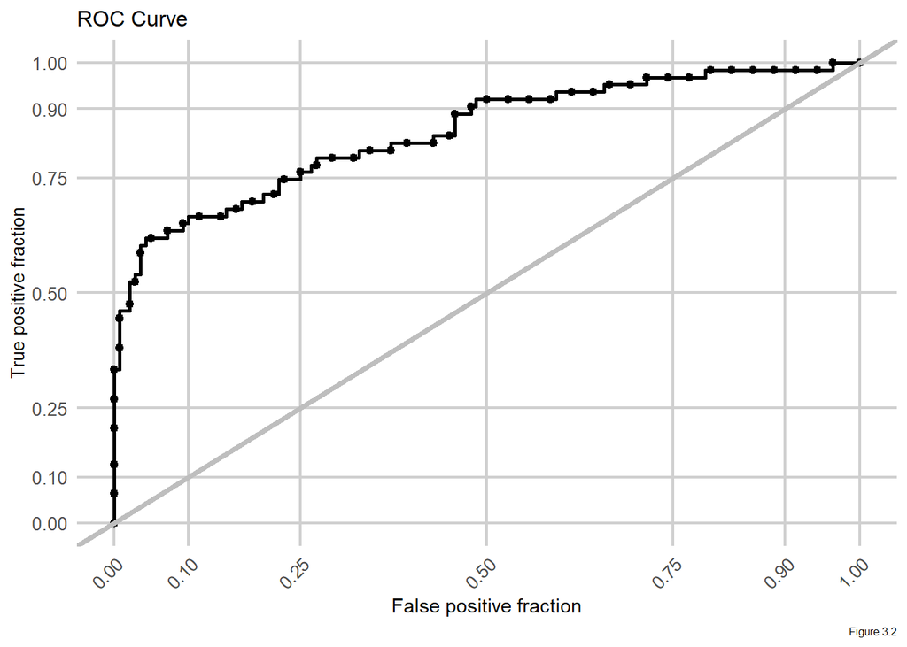

```r
# change obs to numeric
testProbs$obs <- as.numeric(as.character(testProbs$obs))

# plot results
ggplot(testProbs, aes(d = obs, m = pred)) +
  geom_roc(n.cuts = 50, labels = FALSE) +
  style_roc(theme = theme_grey) +
  geom_abline(slope = 1, intercept = 0, size = 1.5, color = 'grey') +
  labs(title="ROC Curve",
       caption = "Figure 3.2") +
  plotTheme
```

```r
#area under the curve
auc(testProbs$obs, testProbs$pred)
```

```
## Area under the curve: 0.8483
```

The Receiver Operating Characteristic curve plots the true positive fraction against the false positive fraction. This plot shows the trade-offs between false positives and negatives and the model’s goodness of fit. Since the ROC Curve (Figure 3.2) lies above the diagonal axis, the model predicts significantly better than a coin flip, making it a useful model.

Additionally, the area under the ROC Curve is 0.85. This signifies that the model effectively distinguishes between positive and negative cases. Moreover, the high area under the curve suggests that the model performs well, with strong and accurate predictive power.

## 3.6: Cross-Validation

```r
ctrl <- trainControl(method = "cv",
                     number = 100,
                     p = 0.7,
                     savePredictions = TRUE)

cvFit <- train(as.factor(flood) ~ .,  data = model_data %>%
                                                as.data.frame(),
               method="glm", family="binomial",
               trControl = ctrl)

cvFit
```

```
## Generalized Linear Model
##
## 680 samples
##   6 predictor
##   2 classes: '0', '1'
##
## No pre-processing
## Resampling: Cross-Validated (100 fold)
## Summary of sample sizes: 673, 674, 673, 673, 674, 673, ...
## Resampling results:
##
##   Accuracy   Kappa
##   0.8600595  0.6255766
```

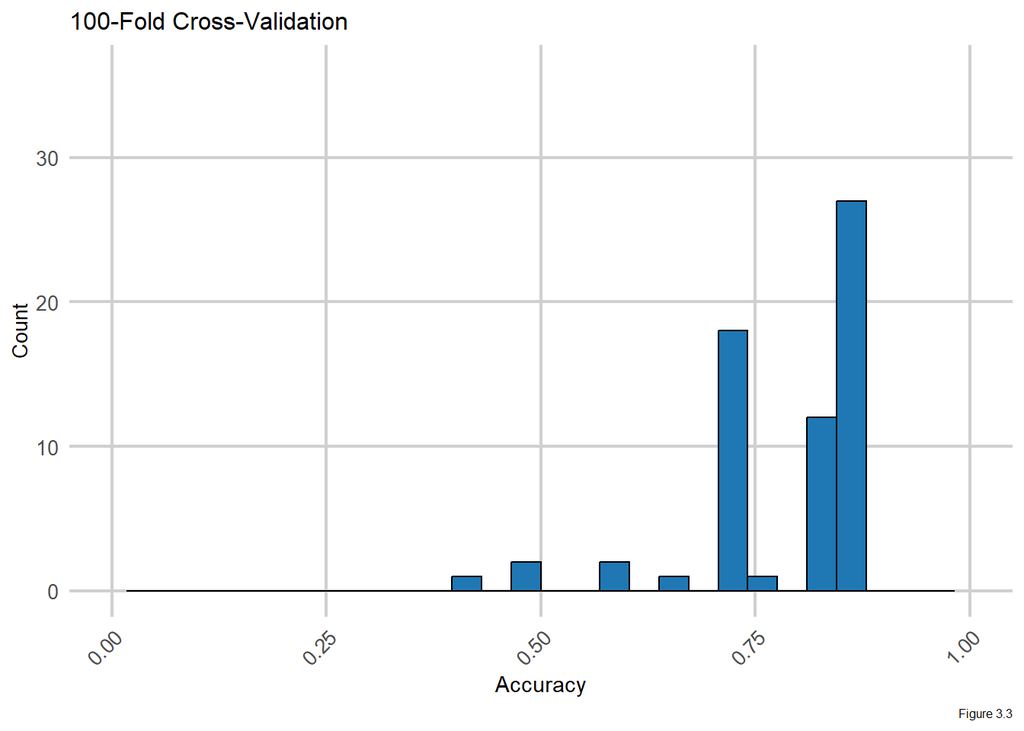

```r
ggplot(as.data.frame(cvFit$resample), aes(Accuracy)) +
  geom_histogram(fill = "#1f78b4", color = "black") +
  scale_x_continuous(limits = c(0, 1)) +
  labs(x="Accuracy",
       y="Count") +
  labs(title="100-Fold Cross-Validation",
       caption = "Figure 3.3")+
  plotTheme
```

# 4: Plotting Outcomes for Calgary

```r
allPredictions <-
  predict(cvFit, model_data, type="prob")[,2]

finalflood <-
  cbind(model_data,allPredictions) %>%
  mutate(allPredictions = round(allPredictions * 100))

joined_fishnet_cal <- calgary_fishnet %>%
  left_join(finalflood, by = "FID")
```

Using our model, we predicted the probability of flood inundation in Calgary. Figure 4.1 depicts the probability of a flood occurring in a given grid cell by quintile.

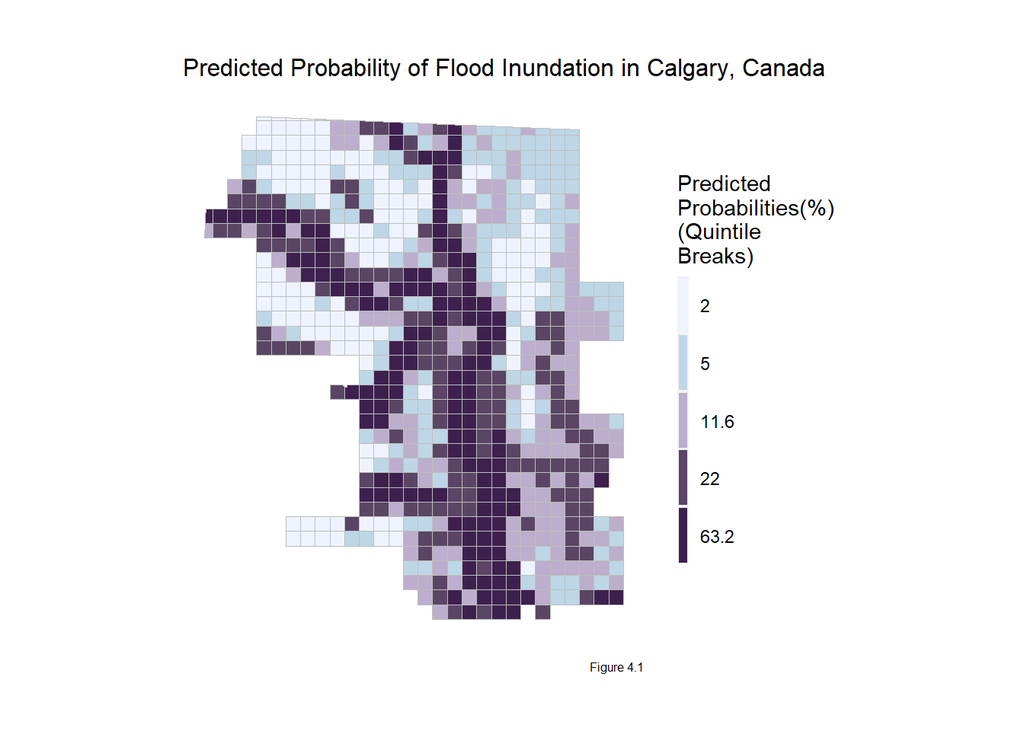

```r
ggplot() +
    geom_sf(data=joined_fishnet_cal, aes(fill=factor(ntile(allPredictions,5))),
            colour=NA) +  # Raster layer
  geom_sf(data = calgary_fishnet, color = "grey", fill = NA) +
    scale_fill_manual(values = c("#eff3ff", "#bdd7e7", "#bcaecc", "#5a4565", "#3e204f"),
                      labels=as.character(quantile(joined_fishnet_cal$allPredictions,
                                                 c(0.1,.2,.4,.6,.8),
                                                 na.rm=T)),
                      name="Predicted\nProbabilities(%)\n(Quintile\nBreaks)") +
  mapTheme +
  labs(title="Predicted Probability of Flood Inundation in Calgary, Canada",
       caption = "Figure 4.1")
```

Figure 4.2 shows an overlay of past flood events over the future probability of a flood occurring. A visual trend from the map is that past flood events correlate highly to predicted future flood events.

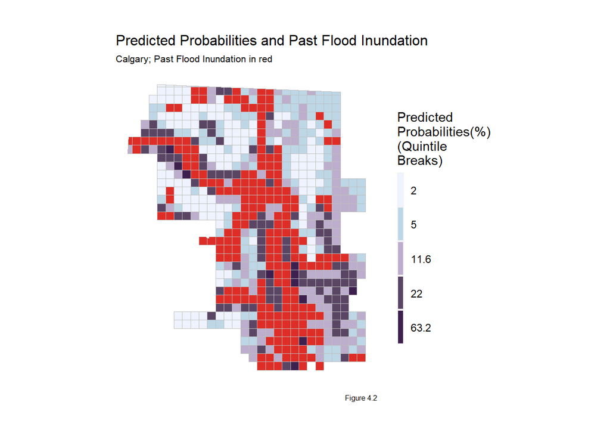

```r
ggplot() +
    geom_sf(data=joined_fishnet_cal, aes(fill=factor(ntile(allPredictions,5))),
            colour=NA) +
    scale_fill_manual(values = c("#eff3ff", "#bdd7e7", "#bcaecc", "#5a4565", "#3e204f"),
                      labels=as.character(quantile(joined_fishnet_cal$allPredictions,
                                                 c(0.1,.2,.4,.6,.8),
                                                 na.rm=T)),
                      name="Predicted\nProbabilities(%)\n(Quintile\nBreaks)") +
  geom_sf(data=joined_fishnet_cal  %>%
               filter(flood == 1),
               fill="#de2d26",colour=NA) +
  geom_sf(data = calgary_fishnet, color = "grey", fill = NA) +
  mapTheme +
  labs(title="Predicted Probabilities and Past Flood Inundation",
       subtitle="Calgary; Past Flood Inundation in red",
       caption = "Figure 4.2")
```

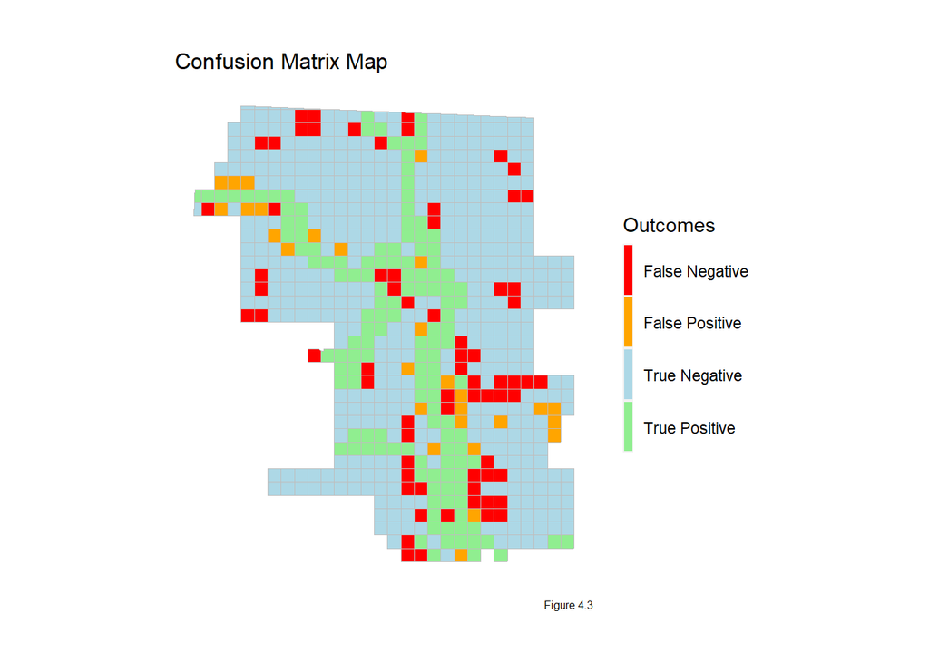

```r
##Confusion Matrix Map
joined_fishnet_cal %>%
  mutate(confResult=case_when(allPredictions < 50 & flood==0 ~ "True Negative",
                              allPredictions >= 50 & flood==1 ~ "True Positive",
                              allPredictions < 50 & flood==1 ~ "False Negative",
                              allPredictions >= 50 & flood==0 ~ "False Positive")) %>%
  ggplot()+
  geom_sf(aes(fill = confResult), color = "transparent")+
   geom_sf(data = calgary_fishnet, color = "grey", fill = NA) +
  scale_fill_manual(values = c("Red","Orange","Light Blue","Light Green"),
                    name="Outcomes")+
  labs(title="Confusion Matrix Map",
       caption = "Figure 4.3") +
  mapTheme
```

This figure displays where the model predicted “Flood” and “No Flood” correctly and incorrectly. The pattern from this map suggests that the model had difficulty predicting floods in areas further away from a water body. We also noticed that the model had more False Negative results in the southern part of Calgary, suggesting that other factors might contribute to flood risk there. Additionally, the False Positive results are clustered around the True Positive cells. This suggests that proximity to waterbody might have resulted in these predictions.

# 5: Applying the Model to Denver, Colorado

## 5.1: Load Data Denver

```r
# independent variables
elevation_den <- read.csv("C:\\Users\\USER\\Desktop\\LandUseModeling\\Assignment3\\Denver\\table\\Zonal_elevation_den.csv")

flow_acc_den <- read.csv("C:\\Users\\USER\\Desktop\\LandUseModeling\\Assignment3\\Denver\\table\\Zonal_fac_den.csv")

land_use_den <- read.csv("C:\\Users\\USER\\Desktop\\LandUseModeling\\Assignment3\\Denver\\table\\Zonal_permea_den.csv")

slope_den <- read.csv("C:\\Users\\USER\\Desktop\\LandUseModeling\\Assignment3\\Denver\\table\\Zonal_slope_den.csv")

water_body_den <- read.csv("C:\\Users\\USER\\Desktop\\LandUseModeling\\Assignment3\\Denver\\table\\Zonal_waterdist_den.csv")
```

## 5.2: Data Cleaning Denver

```r
#1 Elevation
elev_comb_den <- elevation_den %>%
 dplyr::select(FID, MEAN) %>%
  rename(mean_elev= MEAN)

#2 Slope
slope_comb_den <- slope_den %>%
  dplyr::select(FID, MAX) %>%
  rename(max_slope= MAX)

#3 Water body
water_comb_den <- water_body_den %>%
dplyr::select(FID, MIN) %>%
  rename(min_dist_water= MIN)

#4 Flow accumulation
fac_comb_den <-  flow_acc_den %>%
 dplyr::select(FID, MEAN) %>%
  rename(mean_fac= MEAN)
#changed from max to mean

#5 Land Use/Permeability
lu_comb_den <- land_use_den %>%
 dplyr::select(FID, MEAN) %>%
  rename(land_use = MEAN) %>%
  mutate(permeability = case_when(
    land_use < 0.25 ~ '0',
    land_use >= 0.25 ~ '1')) %>%
 dplyr::select(-land_use)
```

## 5.3: Model Building Denver

```r
# Combine all data sets for DENVER model building
model_data_den <- elev_comb_den %>%
  inner_join(slope_comb_den, by = "FID") %>%
  inner_join(water_comb_den, by = "FID") %>%
  inner_join(fac_comb_den, by = "FID") %>%
  inner_join(lu_comb_den, by = "FID") %>%
  mutate(permeability = as.factor(permeability))

# Removing unnecessary data sets
rm(elev_comb_den, slope_comb_den, water_comb_den, fac_comb_den, lu_comb_den)
```

```r
## Denver Independent Maps

denver_fishnet<-st_read("C:\\Users\\USER\\Desktop\\LandUseModeling\\Assignment3\\Denver\\json\\denver_fishnet.json")
denver_boundary<-st_read("C:\\Users\\USER\\Desktop\\LandUseModeling\\Assignment3\\Denver\\json\\denver_boundary.json")
fishnet_shp_den<- st_read("C:/Users/USER/Desktop/LandUseModeling/Assignment3/Denver/denver_boundary.shp")
st_geometry_type(fishnet_shp_den)
```

```
## [1] MULTIPOLYGON
## 18 Levels: GEOMETRY POINT LINESTRING POLYGON MULTIPOINT ... TRIANGLE
```

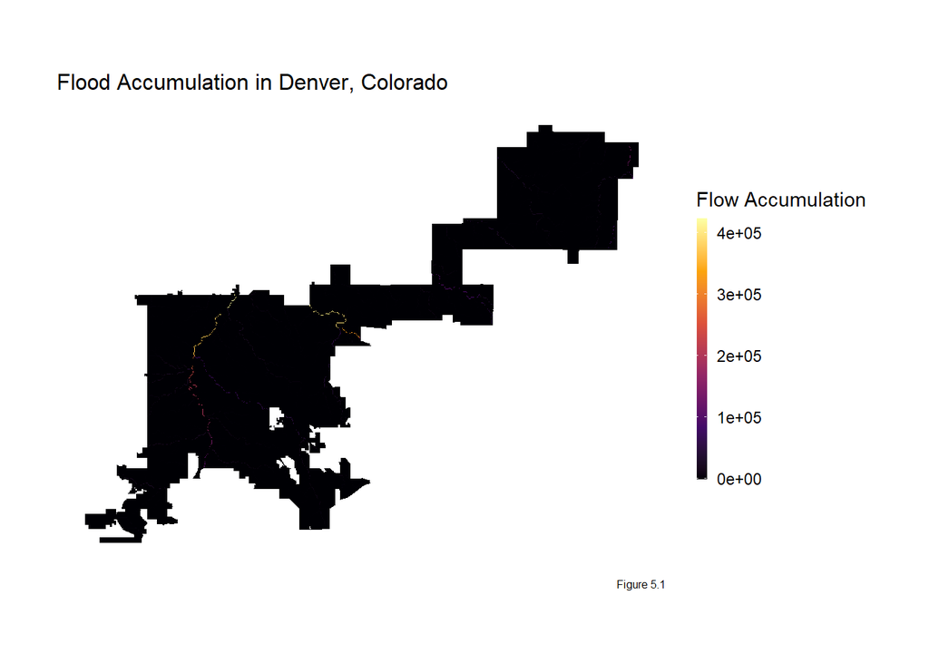

```r
denfishnet_shp <- st_zm(fishnet_shp_den, drop = TRUE)

#Flow Accumulation
den_fac<-raster("C:/Users/USER/Desktop/LandUseModeling/Assignment3/denver_rast/den_fac.tif")
clipped_den_fac <- mask(den_fac,denfishnet_shp )
den_fac_df <-as.data.frame(clipped_den_fac , xy=TRUE)

ggplot() +
    geom_raster(data = den_fac_df , aes(x = x, y = y, fill =den_fac)) +
 scale_fill_viridis_c(name = "Flow Accumulation", option = "inferno", na.value = "transparent",
  limits = c(min(den_fac_df$den_fac, na.rm = TRUE), max(den_fac_df$den_fac, na.rm = TRUE) *1.01))+
  coord_sf() +
  labs(title = "Flood Accumulation in Denver, Colorado",
       caption = "Figure 5.1") +
  mapTheme
```

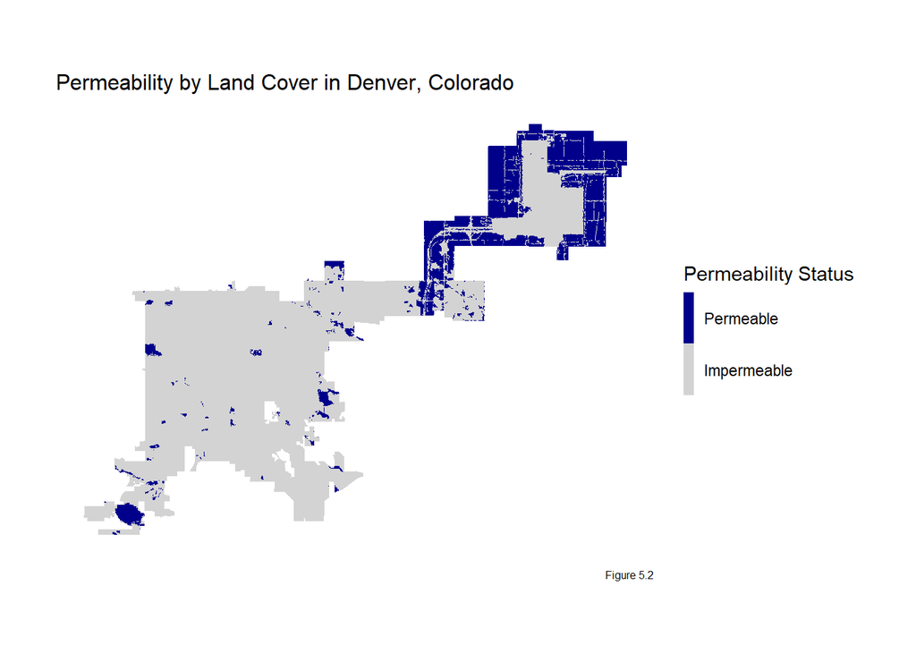

```r
#Permeability
den_perme<-raster("C:/Users/USER/Desktop/LandUseModeling/Assignment3/denver_rast/den_perme.tif")
clipped_den_perme <- mask(den_perme,denfishnet_shp)
den_perme_df <-as.data.frame(clipped_den_perme, xy=TRUE)

den_perme_df$den_perme<-factor(den_perme_df$den_perme)

ggplot() +
  geom_raster(data = den_perme_df, aes(x = x, y = y, fill = den_perme)) +
  geom_tile() +  # Use geom_tile for raster data
  scale_fill_manual(values = c("1" = "#D3D3D3", "0" = "#00008B"),
                    labels = c("1" = "Impermeable", "0" = "Permeable"),
                    name = "Permeability Status",
                     na.value = "transparent") +
  coord_sf() +  # Explicitly use spatial coordinates
  labs(title = "Permeability by Land Cover in Denver, Colorado",
       caption = "Figure 5.2") +
  mapTheme
```

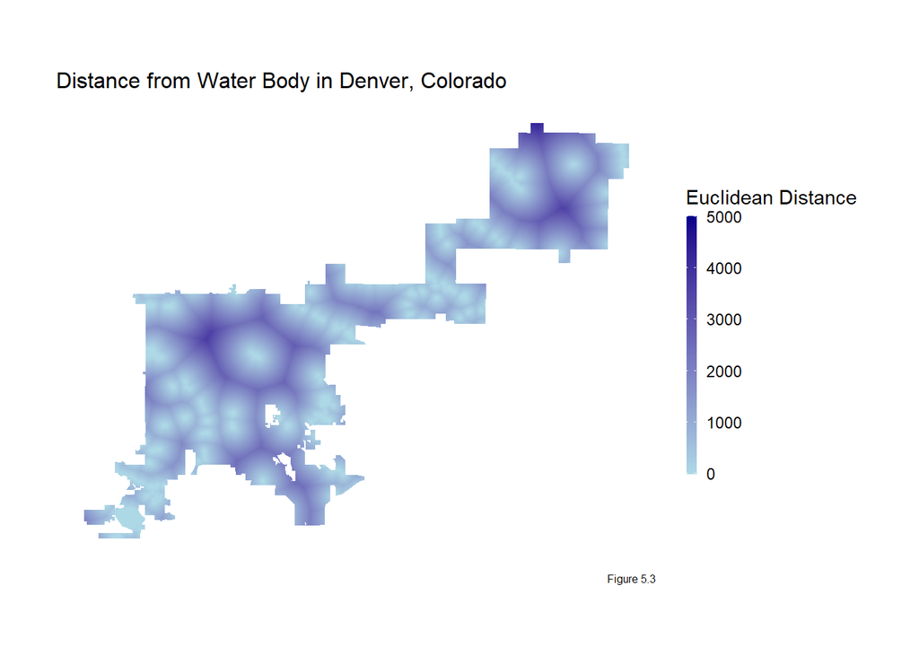

```r
#Distance from water Body
den_water<-raster("C:/Users/USER/Desktop/LandUseModeling/Assignment3/denver_rast/den_water.tif")

clipped_den_water <- mask(den_water,denfishnet_shp)
den_water_df <-as.data.frame(clipped_den_water, xy=TRUE)


ggplot() +
  geom_raster(data = den_water_df , aes(x = x, y = y, fill = den_water)) +
  scale_fill_gradient(name = "Euclidean Distance",
                      low = "lightblue", high = "darkblue",
                      na.value = "transparent",
                      limits = c(NA, 5000)) +
  coord_sf() +
  labs(title = "Distance from Water Body in Denver, Colorado",
       caption = "Figure 5.3") +
  mapTheme
```

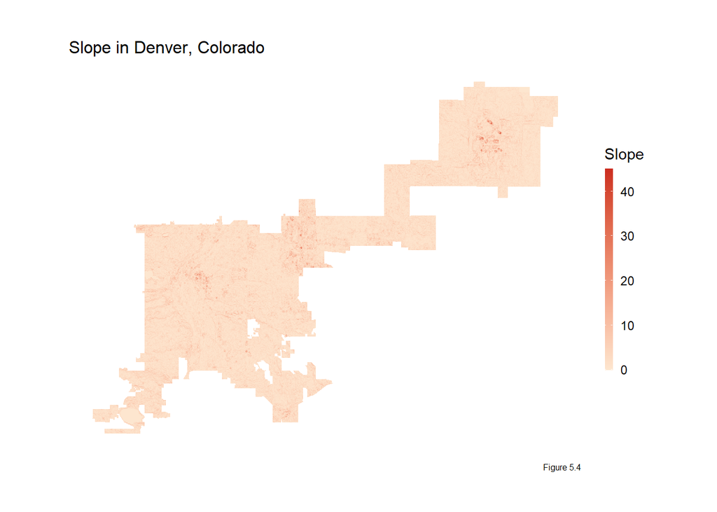

```r
#Slope
denver_slope<-raster("C:/Users/USER/Desktop/LandUseModeling/Assignment3/denver_rast/den_slope.tif")

clipped_den_slope <- mask(denver_slope,denfishnet_shp)
den_slope_df <-as.data.frame(clipped_den_slope, xy=TRUE)

ggplot() +
    geom_raster(data = den_slope_df , aes(x = x, y = y, fill =den_slope)) +
    scale_fill_gradient(name = "Slope",
                      low = "#FDE6CF", high = "#CC2D20",
                      na.value = "transparent",
                      limits = c(NA, 45)) +
  coord_sf() +
      labs(title = "Slope in Denver, Colorado",
       caption = "Figure 5.4") +
  mapTheme
```

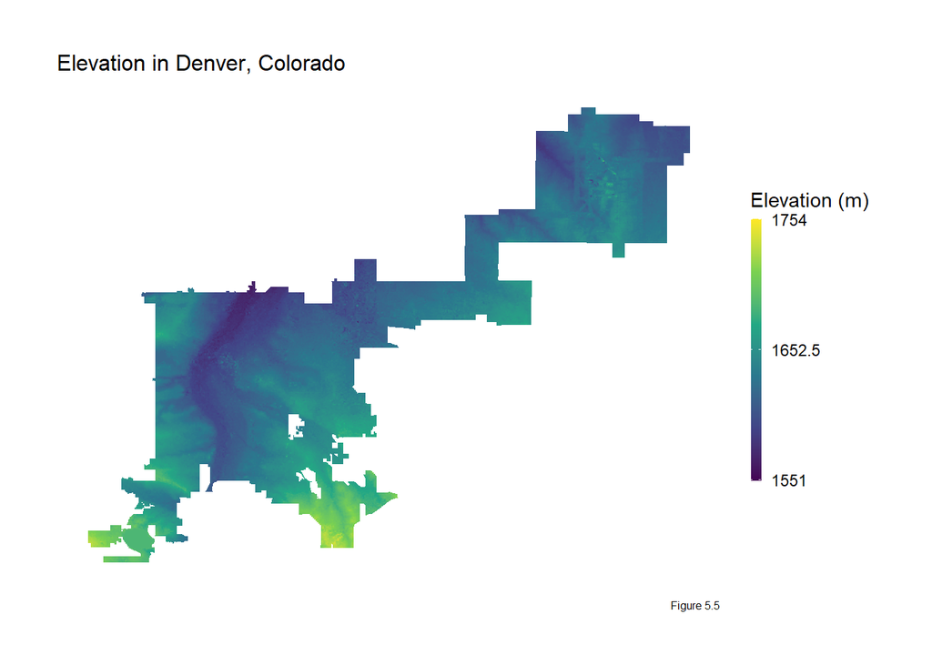

```r
#Elevation
den_dem<-raster("C:/Users/USER/Desktop/LandUseModeling/Assignment3/denver_rast/den_dem.tif")

clipped_den_dem <- mask(den_dem,denfishnet_shp)
den_dem_df <-as.data.frame(clipped_den_dem , xy=TRUE)

lowest_value_den <- 1551
highest_value_den <- 1754

ggplot() +
  geom_raster(data = den_dem_df, aes(x = x, y = y, fill = den_dem)) +
  scale_fill_viridis_c(name = "Elevation (m)",
                       na.value = "transparent",
                       limits = c(lowest_value_den, highest_value_den),
                       breaks = c(lowest_value_den, (lowest_value_den+highest_value_den)/2, highest_value_den),
                       labels = c(as.character(lowest_value_den), as.character((lowest_value_den+highest_value_den)/2), as.character(highest_value_den))) +
  coord_sf() +
  labs(title = "Elevation in Denver, Colorado",
       caption = "Figure 5.5") +
mapTheme
```

## 5.4: Predicting Flood in Denver

The predicted probabilities for flood inundation in Denver, Colorado, are generally very low. We suspect the predictions are skewed because of the variables used in the model. Elevation was a highly significant variable in the model. Denver overall has a higher average elevation than Calgary, which may have impacted the predicted risk of flooding.

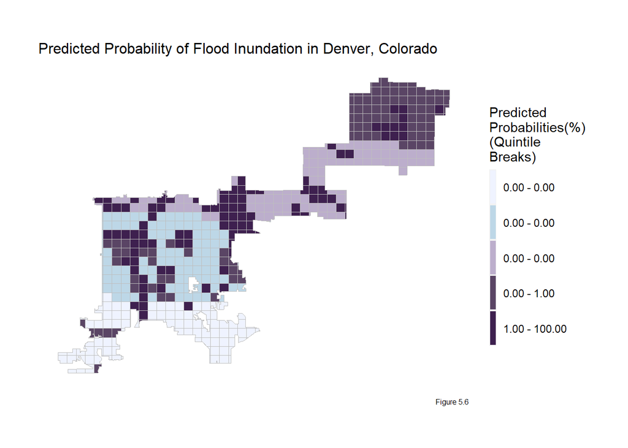

```r
den_classProbs <- predict(floodModel, model_data_den, type = "response")

den_floodModel <- cbind(model_data_den, den_classProbs) %>%
  mutate(allPredictions2 = round(den_classProbs * 100))

joined_fishnet_den <- denver_fishnet %>%
  left_join(den_floodModel , by = "FID")

quantile_breaks <- quantile(joined_fishnet_den$allPredictions2, probs = seq(0, 1, by = 0.2), na.rm = TRUE)
# Create custom labels based on these breaks
custom_labels <- sprintf("%.2f - %.2f", head(quantile_breaks, -1), tail(quantile_breaks, -1))

ggplot() +
    geom_sf(data = joined_fishnet_den, aes(fill = factor(ntile(allPredictions2, 5))), colour = NA) +
    geom_sf(data = denver_fishnet, color = "grey", fill = NA) +
    scale_fill_manual(
      values = c("#eff3ff", "#bdd7e7", "#bcaecc", "#5a4565", "#3e204f"),  # Your color choices
      labels = custom_labels,  # Use the custom labels based on quantile breaks
      name = "Predicted\nProbabilities(%)\n(Quintile\nBreaks)"
    ) +
    labs(title = "Predicted Probability of Flood Inundation in Denver, Colorado",
       caption = "Figure 5.6") +
  mapTheme
```

# 6: Conclusion

Our team believes that building a predictive flood model can be very helpful in guiding planning and policy decisions. We find that our current model performs well in predicting flooding in Calgary. However, we would suggest adjusting the model to increase its sensitivity. Moreover, we found that the model might not generalize well across cities. We suggest looking into engineering other variables, such as climate and rainfall features, that could improve the model’s performance.

# 7: Data Source

Land cover data for Calgary and Denver, specifically regarding permeability and distance from water body, were sourced from the Multi-Resolution Land Characteristics Consortium [(MRLC)](https://www.mrlc.gov/data.). Additionally, the Digital Elevation Model (DEM) for Calgary was obtained from the United States Geological Survey [(USGS)](https://data.usgs.gov/datacatalog/%20with%20the%20dataset%20identifier%2077ae0551-c61e-4979-aedd-d797abdcde0e.).

# 8: Video Presentation

To access our team’s 4-minute presentation briefly discussing this project, [click here](https://youtu.be/4oc8fMTeCb4).